# Lecture 03 — Describing Our Data

Wrangling, summaries, statistics, and our first real comparisons

Bill Perry

2026-07-02

# Where we left off (Lecture 02)

- **Setup** — R and Positron installed; project folders created (`data/`, `figures/`, `scripts/`)
- **R as a calculator** — arithmetic, order of operations, assignment with `<-`
- **Vectors** — `c()`, data types (`numeric`, `character`, `logical`)
- **Functions** — calling built-in functions, reading help with `?`
- **Loading data** — `read_excel()` and `read_csv()`; inspecting with `glimpse()`, `head()`, `dim()`
- **Pipe** — `%>%` reads as “then”; chains steps together
- **First ggplot** — boxplot + `geom_jitter()`, saved as PNG

**Note**

**✅ Key idea from Lecture 02**

You can get data into R and make a plot. Today we learn to *wrangle* and *describe* what we actually have.

# Goals for Today

**Part 1 — Tidyverse wrangling:**

- `filter()` — pick rows by a condition
- `select()` — pick columns by name
- `mutate()` — create new columns
- `arrange()` — sort rows
- Chain them all into a **pipeline**

**Part 2 — Descriptive statistics:**

- mean, median, variance, SD, SE
- NA handling — `sum(!is.na())`
- `group_by()` + `summarize()`
- `skimr` for a fast full overview
- Boxplot + mean ± SE plots

**Tip**

**🖐 Try it yourself**

By the end you will wrangle and describe our leaf data in one connected pipeline.

**Our tools today:**

- `readxl`
- `tidyverse`
- `skimr`

**References:**

- 📖 [R4DS Ch 3](https://r4ds.hadley.nz/data-transform) — Data Transformation
- 📖 [R4DS Ch 13](https://r4ds.hadley.nz/numbers) — Numbers
- 📖 [R4DS Ch 18](https://r4ds.hadley.nz/missing-values) — Missing Values
- 🌐 [Data Carpentry](https://datacarpentry.github.io/R-ecology-lesson/)

**Naming conventions:**

- data frames → `_df`
- plots → `_plot`
- models → `_model`

# Load Libraries and Data

```r
# Load all packages at the top of every script ----------
library(readxl) # reading Excel files
library(tidyverse) # data wrangling + ggplot2
library(skimr) # fast descriptive summaries
```

```r
# Read the leaf data from the data folder ---------------
tree_df <- read_excel("data/2026_06_25_tree_experiment_raw_data.xlsx")
```

**Note**

**Install once — load every session**

- Run in the Console one time only: `install.packages("skimr")`
- Then every session: `library(skimr)` activates it.

# Inspect the Data

```r
# Preview the first rows ----------------------------
head(tree_df)
```

```
# A tibble: 6 × 5
  index side  weight_g width_cm height_cm
  <dbl> <chr>    <dbl>    <dbl>     <dbl>
1     1 sunny        4       12        21
2     2 sunny        3       14        22
3     3 sunny        5       12        21
4     4 sunny        3       13        23
5     5 sunny        4       15        22
6     6 sunny        3       13        23
```

```r
# Column names, types, first values -----------------
glimpse(tree_df)
```

```
Rows: 20
Columns: 5
$ index     <dbl> 1, 2, 3, 4, 5, 6, 7, 8, 9, 10, 11, 12, 13, 14, 15, 16, 17, 1…
$ side      <chr> "sunny", "sunny", "sunny", "sunny", "sunny", "sunny", "sunny…
$ weight_g  <dbl> 4, 3, 5, 3, 4, 3, 5, 4, 3, 4, 7, 8, 6, 9, 8, 7, 8, 9, 9, 7
$ width_cm  <dbl> 12, 14, 12, 13, 15, 13, 16, 13, 14, 15, 9, 18, 17, 18, 19, 1…
$ height_cm <dbl> 21, 22, 21, 23, 22, 23, 21, 24, 23, 23, 28, 29, 27, 28, 27, …
```

```r
# Rows × columns
dim(tree_df)
```

```
[1] 20  5
```

- `<chr>` = character
- `<dbl>` = numeric

# Part 1 · The Core Tidyverse Verbs

Five functions do most of the work in data wrangling:

| Function | What it does |
| --- | --- |
| `filter()` | keep **rows** matching a condition |
| `select()` | keep **columns** by name |
| `mutate()` | **add or change** a column |
| `arrange()` | **sort** rows |
| `summarize()` | **collapse** rows to a summary |

All take a data frame as first input (via `%>%`) and return a data frame.

📖 [R4DS §3 — Data Transformation](https://r4ds.hadley.nz/data-transform)

**Note**

**✅ Key idea**

These five verbs are the tidyverse grammar for data. Learn them once and you can wrangle almost any dataset.

Think of them as building blocks:

```
filter()   → rows you want
select()   → columns you want
mutate()   → new columns you need
arrange()  → order the rows
summarize()→ collapse to summaries
```

# `filter()` — Picking Rows

```r
# filter() keeps rows where the condition is TRUE -------

# Keep only sunny leaves
tree_df %>% filter(side == "sunny") %>% head()
```

```
# A tibble: 6 × 5
  index side  weight_g width_cm height_cm
  <dbl> <chr>    <dbl>    <dbl>     <dbl>
1     1 sunny        4       12        21
2     2 sunny        3       14        22
3     3 sunny        5       12        21
4     4 sunny        3       13        23
5     5 sunny        4       15        22
6     6 sunny        3       13        23
```

```r
# Keep only leaves heavier than 5 g
tree_df %>% filter(weight_g > 5) %>% head()
```

```
# A tibble: 6 × 5
  index side  weight_g width_cm height_cm
  <dbl> <chr>    <dbl>    <dbl>     <dbl>
1    11 shady        7        9        28
2    12 shady        8       18        29
3    13 shady        6       17        27
4    14 shady        9       18        28
5    15 shady        8       19        27
6    16 shady        7       19        28
```

```r
# Combine two conditions with & (AND)
tree_df %>% filter(side == "shady", weight_g > 7) %>% head()
```

```
# A tibble: 6 × 5
  index side  weight_g width_cm height_cm
  <dbl> <chr>    <dbl>    <dbl>     <dbl>
1    12 shady        8       18        29
2    14 shady        9       18        28
3    15 shady        8       19        27
4    17 shady        8       18        29
5    18 shady        9       17        27
6    19 shady        9       19        27
```

**Common comparison operators:**

| Symbol | Meaning |
| --- | --- |
| `==` | exactly equal |
| `!=` | not equal |
| `>` `<` | greater / less than |
| `>=` `<=` | greater / less than or equal |
| is.na | return all NA rows |
| !is.na | return all rows that are **NOT NA** |

**Warning**

**⚠️ Watch out!**

- `=` assigns a value.
- `==` tests equality.
- `filter(side = "sunny")` → error.
- `filter(side == "sunny")` → correct.

# `select()` — Picking Columns

```r
# select() keeps the columns you name ------------------

# Keep only side and weight
tree_df %>% select(side, weight_g) %>% head()
```

```
# A tibble: 6 × 2
  side  weight_g
  <chr>    <dbl>
1 sunny        4
2 sunny        3
3 sunny        5
4 sunny        3
5 sunny        4
6 sunny        3
```

```r
# Drop the index column (use minus sign)
tree_df %>% select(-index) %>% head()
```

```
# A tibble: 6 × 4
  side  weight_g width_cm height_cm
  <chr>    <dbl>    <dbl>     <dbl>
1 sunny        4       12        21
2 sunny        3       14        22
3 sunny        5       12        21
4 sunny        3       13        23
5 sunny        4       15        22
6 sunny        3       13        23
```

```r
# Keep columns that start with a word
tree_df %>% select(starts_with("weight")) %>% head()
```

```
# A tibble: 6 × 1
  weight_g
     <dbl>
1        4
2        3
3        5
4        3
5        4
6        3
```

- **Why `select()` matters:**
  - Real datasets often have 50–100+ columns
  - You rarely need all of them
  - `select()` keeps your workspace clean
- **Useful helpers:**
  - `starts_with("x")` — columns starting with “x”
  - `ends_with("_g")` — columns ending with “_g”
  - `contains("cm")` — columns containing “cm”

📖 [R4DS §3.3](https://r4ds.hadley.nz/data-transform#select)

# `mutate()` — Creating New Columns

```r
# mutate() adds a new column to the data frame ---------

# Convert grams to milligrams
tree_df %>%
  mutate(weight_mg = weight_g * 1000) %>%
  head()
```

```
# A tibble: 6 × 6
  index side  weight_g width_cm height_cm weight_mg
  <dbl> <chr>    <dbl>    <dbl>     <dbl>     <dbl>
1     1 sunny        4       12        21      4000
2     2 sunny        3       14        22      3000
3     3 sunny        5       12        21      5000
4     4 sunny        3       13        23      3000
5     5 sunny        4       15        22      4000
6     6 sunny        3       13        23      3000
```

```r
# Add a size category based on weight
tree_df %>%
  mutate(size_class = if_else(weight_g > 5, "large", "small")) %>%
  head()
```

```
# A tibble: 6 × 6
  index side  weight_g width_cm height_cm size_class
  <dbl> <chr>    <dbl>    <dbl>     <dbl> <chr>
1     1 sunny        4       12        21 small
2     2 sunny        3       14        22 small
3     3 sunny        5       12        21 small
4     4 sunny        3       13        23 small
5     5 sunny        4       15        22 small
6     6 sunny        3       13        23 small
```

```r
# mutate() can reference multiple existing columns
tree_df %>%
  mutate(
    weight_mg = weight_g * 1000,
    area_approx = width_cm * height_cm # rough area estimate
  ) %>%
  head()
```

```
# A tibble: 6 × 7
  index side  weight_g width_cm height_cm weight_mg area_approx
  <dbl> <chr>    <dbl>    <dbl>     <dbl>     <dbl>       <dbl>
1     1 sunny        4       12        21      4000         252
2     2 sunny        3       14        22      3000         308
3     3 sunny        5       12        21      5000         252
4     4 sunny        3       13        23      3000         299
5     5 sunny        4       15        22      4000         330
6     6 sunny        3       13        23      3000         299
```

- `mutate()` keeps **all existing columns** and adds new ones
- **Use `if_else(condition, value_if_true, value_if_false)` to create categories**

**Note**

**✅ Key idea**

`mutate()` never removes columns — it adds to the right of your data frame.

To overwrite a column, just use the same name on the left: `mutate(weight_g = round(weight_g, 1))`

📖 [R4DS §3.3](https://r4ds.hadley.nz/data-transform#sec-mutate)

# `arrange()` — Sorting Rows

```r
# arrange() sorts rows by one or more columns ----------

# Lightest leaves first
tree_df %>% arrange(weight_g)
```

```
# A tibble: 20 × 5
   index side  weight_g width_cm height_cm
   <dbl> <chr>    <dbl>    <dbl>     <dbl>
 1     2 sunny        3       14        22
 2     4 sunny        3       13        23
 3     6 sunny        3       13        23
 4     9 sunny        3       14        23
 5     1 sunny        4       12        21
 6     5 sunny        4       15        22
 7     8 sunny        4       13        24
 8    10 sunny        4       15        23
 9     3 sunny        5       12        21
10     7 sunny        5       16        21
11    13 shady        6       17        27
12    11 shady        7        9        28
13    16 shady        7       19        28
14    20 shady        7       19        29
15    12 shady        8       18        29
16    15 shady        8       19        27
17    17 shady        8       18        29
18    14 shady        9       18        28
19    18 shady        9       17        27
20    19 shady        9       19        27
```

```r
# Heaviest leaves first (use desc() to reverse)
tree_df %>% arrange(desc(weight_g))
```

```
# A tibble: 20 × 5
   index side  weight_g width_cm height_cm
   <dbl> <chr>    <dbl>    <dbl>     <dbl>
 1    14 shady        9       18        28
 2    18 shady        9       17        27
 3    19 shady        9       19        27
 4    12 shady        8       18        29
 5    15 shady        8       19        27
 6    17 shady        8       18        29
 7    11 shady        7        9        28
 8    16 shady        7       19        28
 9    20 shady        7       19        29
10    13 shady        6       17        27
11     3 sunny        5       12        21
12     7 sunny        5       16        21
13     1 sunny        4       12        21
14     5 sunny        4       15        22
15     8 sunny        4       13        24
16    10 sunny        4       15        23
17     2 sunny        3       14        22
18     4 sunny        3       13        23
19     6 sunny        3       13        23
20     9 sunny        3       14        23
```

```r
# Sort by side, then by weight within each side
tree_df %>% arrange(side, desc(weight_g))
```

```
# A tibble: 20 × 5
   index side  weight_g width_cm height_cm
   <dbl> <chr>    <dbl>    <dbl>     <dbl>
 1    14 shady        9       18        28
 2    18 shady        9       17        27
 3    19 shady        9       19        27
 4    12 shady        8       18        29
 5    15 shady        8       19        27
 6    17 shady        8       18        29
 7    11 shady        7        9        28
 8    16 shady        7       19        28
 9    20 shady        7       19        29
10    13 shady        6       17        27
11     3 sunny        5       12        21
12     7 sunny        5       16        21
13     1 sunny        4       12        21
14     5 sunny        4       15        22
15     8 sunny        4       13        24
16    10 sunny        4       15        23
17     2 sunny        3       14        22
18     4 sunny        3       13        23
19     6 sunny        3       13        23
20     9 sunny        3       14        23
```

- Default: **ascending** order (smallest first)
- `desc(column)` → **descending** order (largest first)
- Very useful before printing a table or checking outliers

**Tip**

`arrange()` is rarely used in the middle of an analysis pipeline — it is most useful at the **end** when you want to inspect your results in a specific order.

# The Full Pipeline

```r
# Chain all the verbs together -------------------------
# Read it top to bottom like a recipe

wrangled_df <- tree_df %>%
  filter(weight_g > 0) %>% # remove any zeros
  select(side, weight_g, height_cm) %>% # keep only needed cols
  mutate(
    weight_mg = weight_g * 1000,
    size_class = if_else(weight_g > 5, "large", "small")
  ) %>%
  arrange(side, desc(weight_g)) # sort by side, then weight

head(wrangled_df)
```

```
# A tibble: 6 × 5
  side  weight_g height_cm weight_mg size_class
  <chr>    <dbl>     <dbl>     <dbl> <chr>
1 shady        9        28      9000 large
2 shady        9        27      9000 large
3 shady        9        27      9000 large
4 shady        8        29      8000 large
5 shady        8        27      8000 large
6 shady        8        29      8000 large
```

**Read the pipeline out loud:**

> - Take `tree_df`,
>   - **then** filter to non-zero weights,
>     - **then** select three columns,
>       - **then** add two new columns,
>         - **then** sort by side and weight.

**Note**

**✅ Key idea**

The pipeline `%>%` is what makes tidyverse readable. You can see every step in order — unlike nested function calls that read inside-out.

# Part 2 · Our Scientific Question

**Biological prediction:** Leaves on the *shady* side of a tree will be **larger and heavier** to capture more of the limited light.

|  | Hypothesis |
| --- | --- |
| **H₀ — null** | No difference in leaf size between sunny and shady sides |
| **Hₐ — alternate** | Leaf size differs between sunny and shady sides |

**Plan for this unit:**

1. **Today** — *describe* the data
2. **Lecture 04** — formally *test* the hypotheses with a t-test

Statistics helps us decide which hypothesis is better supported by the data.

# What Is the Mean?

$$\bar{x} = \frac{\sum_{i=1}^{n} x_i}{n}$$

- Add up all values, divide by *n*
- The **balance point** of the distribution
- **Sensitive to outliers** — one very large value pulls the mean up

**Example:**

Values: 5, 6, 7, 8, **50** → mean = 15.2

*Is 15.2 a fair summary? Not really — the outlier dominates!*

**Why it matters:**

- The most commonly reported statistic
- Used in every t-test, ANOVA, and regression
- Always pair it with a measure of **spread** (SD or SE)

📖 [R4DS §13 — Numbers](https://r4ds.hadley.nz/numbers)

# Calculating the Mean — filter() and pull()

```r
# Use filter() + pull() to extract one group's values --
sunny_wt <- tree_df %>%
  filter(side == "sunny") %>%
  pull(weight_g)

sunny_wt # look at the raw values
```

```
 [1] 4 3 5 3 4 3 5 4 3 4
```

```r
# Calculate the mean -----------------------------------
mean_sunny <- mean(sunny_wt, na.rm = TRUE)
cat("Mean sunny weight:", round(mean_sunny, 2), "g\n")
```

```
Mean sunny weight: 3.8 g
```

- `filter(side == "sunny")` — keeps only sunny rows
- `pull(weight_g)` — extracts that column as a **vector**
- `na.rm = TRUE` — removes any `NA` before computing

**Key pattern:**

`filter()` → picks **rows**

`pull()` → extracts a **column** as a vector

📖 [R4DS §3 — Data Transformation](https://r4ds.hadley.nz/data-transform)

# What Is the Median?

**The middle value when data are sorted**

| Sorted data | Median |
| --- | --- |
| 5, 6, **7**, 8, 50 | **7** |
| 5, 6, **7, 8**, 50, 51 | **(7 + 8) / 2 = 7.5** |

- Not pulled by outliers → **robust**
- If **mean ≫ median** → right-skewed
- If **mean ≈ median** → roughly symmetric

```r
# Median for each side ---------------------------------
shady_wt <- tree_df %>%
  filter(side == "shady") %>%
  pull(weight_g)

med_sunny <- median(sunny_wt, na.rm = TRUE)
med_shady <- median(shady_wt, na.rm = TRUE)

cat("Median sunny:", round(med_sunny, 2), "\n")
```

```
Median sunny: 4
```

```r
cat("Median shady:", round(med_shady, 2), "\n")
```

```
Median shady: 8
```

# What Is Variance?

$$s^2 = \frac{\sum_{i=1}^{n}(x_i - \bar{x})^2}{n - 1}$$

1. For each value, compute distance from mean: $(x_i - \bar{x})$
2. **Square** those distances → all positive
3. Sum them up, divide by $n - 1$

Dividing by $n - 1$ gives an **unbiased** estimate of population variance.

**Larger variance = more spread = more uncertainty**

```r
# Variance for each side ------------------------------
var_sunny <- var(sunny_wt, na.rm = TRUE)
var_shady <- var(shady_wt, na.rm = TRUE)

cat("Variance sunny:", round(var_sunny, 2), "\n")
```

```
Variance sunny: 0.62
```

```r
cat("Variance shady:", round(var_shady, 2), "\n")
```

```
Variance shady: 1.07
```

**Note**

Variance is in **squared units** (g²) — hard to interpret. That is why we use SD.

📖 [R4DS §13.3](https://r4ds.hadley.nz/numbers#numeric-summaries)

# What Is Standard Deviation?

$$s = \sqrt{s^2} = \sqrt{\frac{\sum(x_i - \bar{x})^2}{n-1}}$$

- The **square root of variance** → back in original units (g) ✓
- For a normal distribution:
  - ~**68%** of values fall within mean ± 1 SD
  - ~**95%** fall within mean ± 2 SD
- Reports how spread out *individual* data points are

```r
# Standard deviation for each side -------------------
sd_sunny <- sd(sunny_wt, na.rm = TRUE)
sd_shady <- sd(shady_wt, na.rm = TRUE)

cat("SD sunny:", round(sd_sunny, 2), "g\n")
```

```
SD sunny: 0.79 g
```

```r
cat("SD shady:", round(sd_shady, 2), "g\n")
```

```
SD shady: 1.03 g
```

# What Is Standard Error?

$$SE = \frac{s}{\sqrt{n}}$$

- Measures how precisely we know the **mean**
- Not the spread of raw data — the **uncertainty of the mean itself**
- Gets **smaller** as *n* increases → more data = more precise estimate

|  | Describes |
| --- | --- |
| **SD** | spread of *individual* data points |
| **SE** | precision of the *sample mean* |

We report SE when making claims about group means.

```r
# SE = SD / sqrt(n) — need correct n -----------------
n_sunny <- sum(!is.na(sunny_wt))
n_shady <- sum(!is.na(shady_wt))

se_sunny <- sd_sunny / sqrt(n_sunny)
se_shady <- sd_shady / sqrt(n_shady)

cat("n sunny  =", n_sunny, "\n")
```

```
n sunny  = 10
```

```r
cat("SE sunny =", round(se_sunny, 2), "g\n\n")
```

```
SE sunny = 0.25 g
```

```r
cat("n shady  =", n_shady, "\n")
```

```
n shady  = 10
```

```r
cat("SE shady =", round(se_shady, 2), "g\n")
```

```
SE shady = 0.33 g
```

# The Problem with `length()`

```r
# length() counts ALL positions — including NAs -------
x <- c(4, 3, NA, 7, NA) # a vector with missing values

length(x) # returns 5 — but 2 are NA!
```

```
[1] 5
```

```r
sum(is.na(x)) # how many NAs are there?
```

```
[1] 2
```

```r
# Using length() in SE gives the WRONG answer ---------
wrong_n <- length(x)
wrong_se <- sd(x, na.rm = TRUE) / sqrt(wrong_n)

cat("Wrong n  =", wrong_n, "\n")
```

```
Wrong n  = 5
```

```r
cat("Wrong SE =", round(wrong_se, 3), "\n")
```

```
Wrong SE = 0.931
```

- `length(x)` counts **all positions** in the vector — including `NA`
- This is a **silent error** — R will not warn you!
- Using n = 5 in SE = SD / √n when n should be 3 gives the wrong answer

📖 [R4DS §18 — Missing Values](https://r4ds.hadley.nz/missing-values)

# Fix — `sum(!is.na())`

```r
# Break it down step by step -------------------------
x <- c(4, 3, NA, 7, NA)

is.na(x) # TRUE where NA, FALSE where real
```

```
[1] FALSE FALSE  TRUE FALSE  TRUE
```

```r
!is.na(x) # FLIP: TRUE where real, FALSE where NA
```

```
[1]  TRUE  TRUE FALSE  TRUE FALSE
```

```r
sum(!is.na(x)) # count the TRUEs = number of real values
```

```
[1] 3
```

```r
# Apply to our real leaf data ------------------------
n_sun_check <- sum(!is.na(sunny_wt))
cat("Non-missing sunny weights =", n_sun_check, "\n")
```

```
Non-missing sunny weights = 10
```

**How it works step by step:**

1. `is.na(x)` → `TRUE` for each `NA`
2. `!is.na(x)` → flips it: `TRUE` for **real** values
3. `sum(...)` → counts `TRUE`s

**Tip**

**Best practice:** always use `sum(!is.na(x))` when you need *n* — even when you think there are no NAs.

# All Stats — Base R, One Group at a Time

```r
# All stats for the sunny side -----------------------
n_s <- sum(!is.na(sunny_wt))
mean_s <- mean(sunny_wt, na.rm = TRUE)
med_s <- median(sunny_wt, na.rm = TRUE)
sd_s <- sd(sunny_wt, na.rm = TRUE)
se_s <- sd_s / sqrt(n_s)

cat("--- Sunny Leaves ---\n")
```

```
--- Sunny Leaves ---
```

```r
cat("n      =", n_s, "\n")
```

```
n      = 10
```

```r
cat("Mean   =", round(mean_s, 2), "\n")
```

```
Mean   = 3.8
```

```r
cat("Median =", round(med_s, 2), "\n")
```

```
Median = 4
```

```r
cat("SD     =", round(sd_s, 2), "\n")
```

```
SD     = 0.79
```

```r
cat("SE     =", round(se_s, 2), "\n")
```

```
SE     = 0.25
```

- Every function takes `na.rm = TRUE`
- `cat()` prints clean labelled output
- This is **clear** but repetitive for many groups → that is why we use `group_by()` next

# Stats the Tidy Way — `group_by()` + `summarize()`

```r
# Calculate all stats for both sides at once ----------
stats_df <- tree_df %>%
  group_by(side) %>%
  summarize(
    n = sum(!is.na(weight_g)),
    mean_wt = round(mean(weight_g, na.rm = TRUE), 2),
    med_wt = round(median(weight_g, na.rm = TRUE), 2),
    sd_wt = round(sd(weight_g, na.rm = TRUE), 2),
    se_wt = round(sd_wt / sqrt(n), 2)
  )

stats_df
```

```
# A tibble: 2 × 6
  side      n mean_wt med_wt sd_wt se_wt
  <chr> <int>   <dbl>  <dbl> <dbl> <dbl>
1 shady    10     7.8      8  1.03  0.33
2 sunny    10     3.8      4  0.79  0.25
```

- `group_by(side)` — splits the data by the `side` column
- `summarize()` — collapses each group to one row of stats
- You get **both groups in one clean table**
- You can reference a column just created (`sd_wt` → `se_wt`)

📖 [R4DS §3.5 — `summarize()`](https://r4ds.hadley.nz/data-transform#sec-summarize)

# Multiple Variables at Once

```r
# One group_by() pipe summarizes all measurements -----
size_stats_df <- tree_df %>%
  group_by(side) %>%
  summarize(
    n = sum(!is.na(weight_g)),
    mean_wt = round(mean(weight_g, na.rm = TRUE), 2),
    mean_ht = round(mean(height_cm, na.rm = TRUE), 2),
    mean_wd = round(mean(width_cm, na.rm = TRUE), 2)
  )

size_stats_df
```

```
# A tibble: 2 × 5
  side      n mean_wt mean_ht mean_wd
  <chr> <int>   <dbl>   <dbl>   <dbl>
1 shady    10     7.8    27.9    17.3
2 sunny    10     3.8    22.3    13.7
```

**With one `group_by()` pipe** you summarize **all three measurements** across both sides.

**Do the numbers support our hypothesis?**

- Shady heavier? → check `mean_wt`
- Shady taller? → check `mean_ht`
- Shady wider? → check `mean_wd`

# Fast Summaries with `skimr`

```r
# skim() grouped by side — full column summaries ------
tree_df %>%
  group_by(side) %>%
  skim()
```

Data summary

| Name | Piped data |
| --- | --- |
| Number of rows | 20 |
| Number of columns | 5 |
| _______________________ |  |
| Column type frequency: |  |
| numeric | 4 |
| ________________________ |  |
| Group variables | side |

**Variable type: numeric**

| skim_variable | side | n_missing | complete_rate | mean | sd | p0 | p25 | p50 | p75 | p100 | hist |
| --- | --- | --- | --- | --- | --- | --- | --- | --- | --- | --- | --- |
| index | shady | 0 | 1 | 15.5 | 3.03 | 11 | 13.25 | 15.5 | 17.75 | 20 | ▇▇▇▇▇ |
| index | sunny | 0 | 1 | 5.5 | 3.03 | 1 | 3.25 | 5.5 | 7.75 | 10 | ▇▇▇▇▇ |
| weight_g | shady | 0 | 1 | 7.8 | 1.03 | 6 | 7.00 | 8.0 | 8.75 | 9 | ▂▇▁▇▇ |
| weight_g | sunny | 0 | 1 | 3.8 | 0.79 | 3 | 3.00 | 4.0 | 4.00 | 5 | ▇▁▇▁▃ |
| width_cm | shady | 0 | 1 | 17.3 | 3.02 | 9 | 17.25 | 18.0 | 19.00 | 19 | ▁▁▁▂▇ |
| width_cm | sunny | 0 | 1 | 13.7 | 1.34 | 12 | 13.00 | 13.5 | 14.75 | 16 | ▅▇▅▅▂ |
| height_cm | shady | 0 | 1 | 27.9 | 0.88 | 27 | 27.00 | 28.0 | 28.75 | 29 | ▇▁▆▁▆ |
| height_cm | sunny | 0 | 1 | 22.3 | 1.06 | 21 | 21.25 | 22.5 | 23.00 | 24 | ▆▃▁▇▂ |

Per column and per group: `n_missing`, `mean`, `sd`, percentiles (`p0` to `p100`), and a mini histogram.

**Tip**

`skim()` is your fastest **first look** at any dataset. Pair it with `group_by()` to compare groups instantly.

# Boxplot — Basic Structure

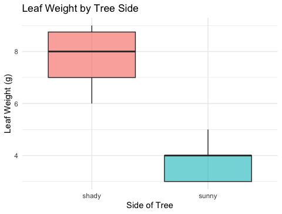

```r
# Basic boxplot — data is already long format ---------
tree_box_plot <- tree_df %>%
  ggplot(aes(x = side, y = weight_g, fill = side)) +
  geom_boxplot(alpha = 0.6, outlier.shape = NA) +
  labs(
    title = "Leaf Weight by Tree Side",
    x = "Side of Tree",
    y = "Leaf Weight (g)",
    fill = "Side"
  ) +
  theme_minimal() +
  theme(legend.position = "none")

tree_box_plot
```

**Boxplot anatomy:**

- Middle line = **median**
- Box edges = 25th and 75th percentile (**IQR**)
- Whiskers = 1.5 × IQR
- Dots beyond whiskers = **outliers**

Because our data is in **long format**, `ggplot2` reads `side` straight off the x-axis — no reshaping needed.

📖 [R4DS §9 — Layers](https://r4ds.hadley.nz/layers)

# Boxplot — Overlay Individual Points

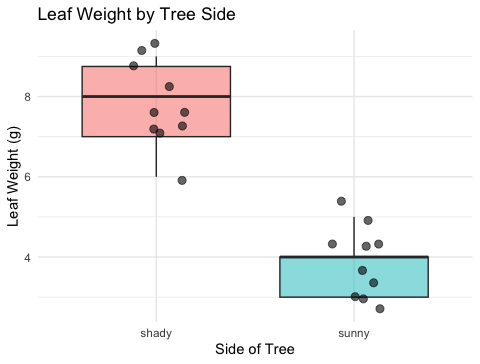

```r
# Add raw data points over the boxplot ----------------
tree_jitter_plot <- tree_df %>%
  ggplot(aes(x = side, y = weight_g, fill = side)) +
  geom_boxplot(alpha = 0.5, outlier.shape = NA) +
  geom_point(
    position = position_jitter(width = 0.15, seed = 42),
    alpha = 0.6,
    size = 2.5
  ) +
  labs(
    title = "Leaf Weight by Tree Side",
    x = "Side of Tree",
    y = "Leaf Weight (g)",
    fill = "Side"
  ) +
  theme_minimal() +
  theme(legend.position = "none")

tree_jitter_plot
```

**Key arguments:**

- `position_jitter(width = 0.15)` — spreads points left and right
- `seed = 42` — same jitter layout every render
- `alpha = 0.6` — semi-transparent to show overlap
- `size = 2.5` — point size

**Tip**

Always show raw points with a boxplot — with only 10 leaves per group, every point matters!

# Mean ± SE Plot — `stat_summary()`

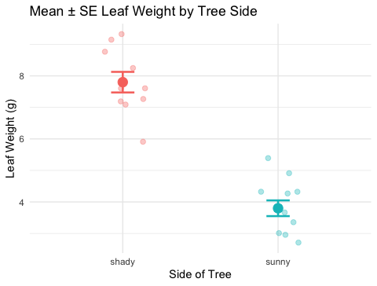

```r
# stat_summary() computes and plots mean and SE -------
tree_mean_se_plot <- tree_df %>%
  ggplot(aes(x = side, y = weight_g, color = side)) +
  geom_point(
    position = position_jitter(width = 0.15, seed = 42),
    alpha = 0.35,
    size = 2
  ) +
  stat_summary(fun = mean, geom = "point", size = 4) +
  stat_summary(
    fun.data = mean_se,
    geom = "errorbar",
    width = 0.15,
    linewidth = 0.9
  ) +
  labs(
    title = "Mean ± SE Leaf Weight by Tree Side",
    x = "Side of Tree",
    y = "Leaf Weight (g)",
    color = "Side"
  ) +
  theme_minimal() +
  theme(legend.position = "none")

tree_mean_se_plot
```

**Two `stat_summary()` layers:**

| call | what it draws |
| --- | --- |
| `fun = mean` | large point at the mean |
| `fun.data = mean_se` | error bars for ± 1 SE |

- Individual points in the **background** (`alpha = 0.35`)
- Mean shown as a **larger foreground point**
- Error bars = **± 1 SE**

# What We Learned Today

- **R wrangling skills:**
  - `filter()` — keep rows by condition
  - `select()` — keep columns by name
  - `mutate()` — add new calculated columns
  - `arrange()` — sort rows
  - Full pipeline: chain all verbs with `%>%`
- **Statistics concepts:**
  - **Mean** — balance point; sensitive to outliers
  - **Median** — middle value; robust
  - **Variance / SD** — spread of individual data
  - **SE** — precision of the sample mean
- **More R skills:**
  - `group_by()` + `summarize()` — all stats for all groups at once
  - `sum(!is.na())` — the right way to count *n*
  - `skim()` — instant full dataset overview
  - `geom_boxplot()` + `geom_point()`, `stat_summary()`

**References:**

- 📖 [R4DS §3](https://r4ds.hadley.nz/data-transform) — Data Transformation
- 📖 [R4DS §13](https://r4ds.hadley.nz/numbers) — Numbers
- 📖 [R4DS §18](https://r4ds.hadley.nz/missing-values) — Missing Values
- 🌐 [Data Carpentry](https://datacarpentry.github.io/R-ecology-lesson/)

**Up next — Lecture 04:**

- Two-sample t-test
- Checking assumptions (normality, equal variance)
- Interpreting and reporting results